# Wahlergebnisse und Alter

```r
library(tidyverse)
```

```r
theme_set(theme_light())
options(repr.plot.res = 150)
```

```r
data <- read_tsv("btw2021_wuerzburg_age.tsv")
```

```r
head(data)
```

A tibble: 6 × 8

| Ort <chr> | Partei <chr> | Stadt <lgl> | Durchschnittsalter <dbl> | Erststimmen <dbl> | ErststimmenAnteil <dbl> | Zweitstimmen <dbl> | ZweitstimmenAnteil <dbl> |
| --- | --- | --- | --- | --- | --- | --- | --- |
| Altertheim | Alternative für Deutschland | FALSE | 44.0 | 0 | 0 | 105 | 0.07749077 |
| Bergtheim | Alternative für Deutschland | FALSE | 42.4 | 0 | 0 | 180 | 0.07120253 |
| Bieberehren | Alternative für Deutschland | FALSE | 45.1 | 0 | 0 | 47 | 0.07742998 |
| Eisingen | Alternative für Deutschland | FALSE | 44.3 | 0 | 0 | 138 | 0.06442577 |
| Erlabrunn | Alternative für Deutschland | FALSE | 43.5 | 0 | 0 | 49 | 0.03895072 |
| Estenfeld | Alternative für Deutschland | FALSE | 44.5 | 0 | 0 | 197 | 0.05392828 |

## Altersverteilung in den Ortschaften

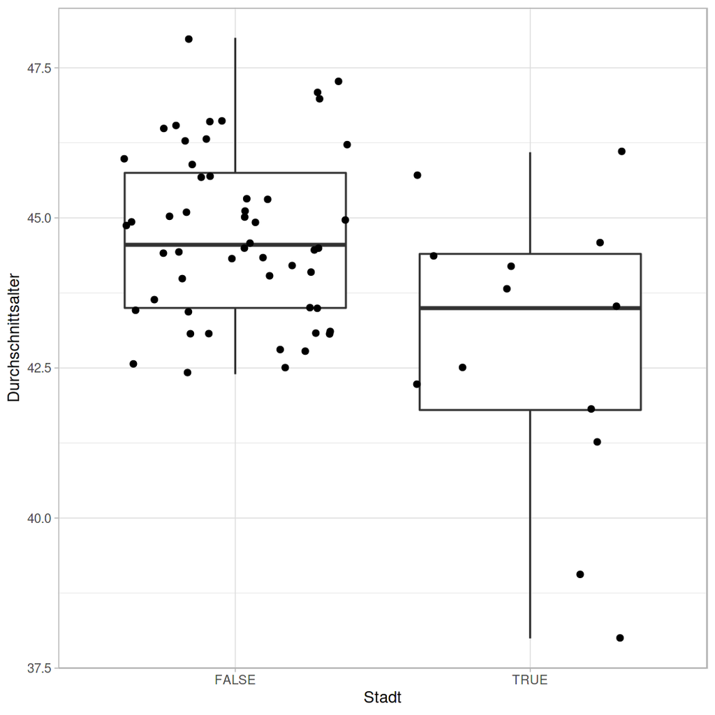

```r
data %>% select(Ort, Stadt, Durchschnittsalter) %>% unique %>% ggplot(aes(Stadt, Durchschnittsalter)) + geom_boxplot() + geom_jitter()
```

Das Durchschnittsalter auf dem Land liegt etwa zwischen 42.5 und 47.5 das in der Stadt zwischen 37.5 und 46. Unterschiede zwischen einzelnen Orten sind also nicht riesig aber doch erkennbar.

Die jüngsten und die ältesten Ortschaften sind:

```r
data %>% select(Ort, Stadt, Durchschnittsalter) %>% unique %>% slice_min(n=5, Durchschnittsalter)
data %>% select(Ort, Stadt, Durchschnittsalter) %>% unique %>% slice_max(n=5, Durchschnittsalter)
```

A tibble: 5 × 3

| Ort <chr> | Stadt <lgl> | Durchschnittsalter <dbl> |
| --- | --- | --- |
| Grombühl | TRUE | 38.0 |
| Altstadt | TRUE | 39.1 |
| Frauenland | TRUE | 41.3 |
| Zellerau | TRUE | 41.8 |
| Rottenbauer | TRUE | 42.2 |

A tibble: 6 × 3

| Ort <chr> | Stadt <lgl> | Durchschnittsalter <dbl> |
| --- | --- | --- |
| Margetshöchheim | FALSE | 48.0 |
| Markt Winterhausen | FALSE | 47.3 |
| Holzkirchen | FALSE | 47.1 |
| Stadt Röttingen | FALSE | 47.0 |
| Riedenheim | FALSE | 46.6 |
| Stadt Eibelstadt | FALSE | 46.6 |

## Korrelation zwischen Parteien (Zweitstimmen) und Alter

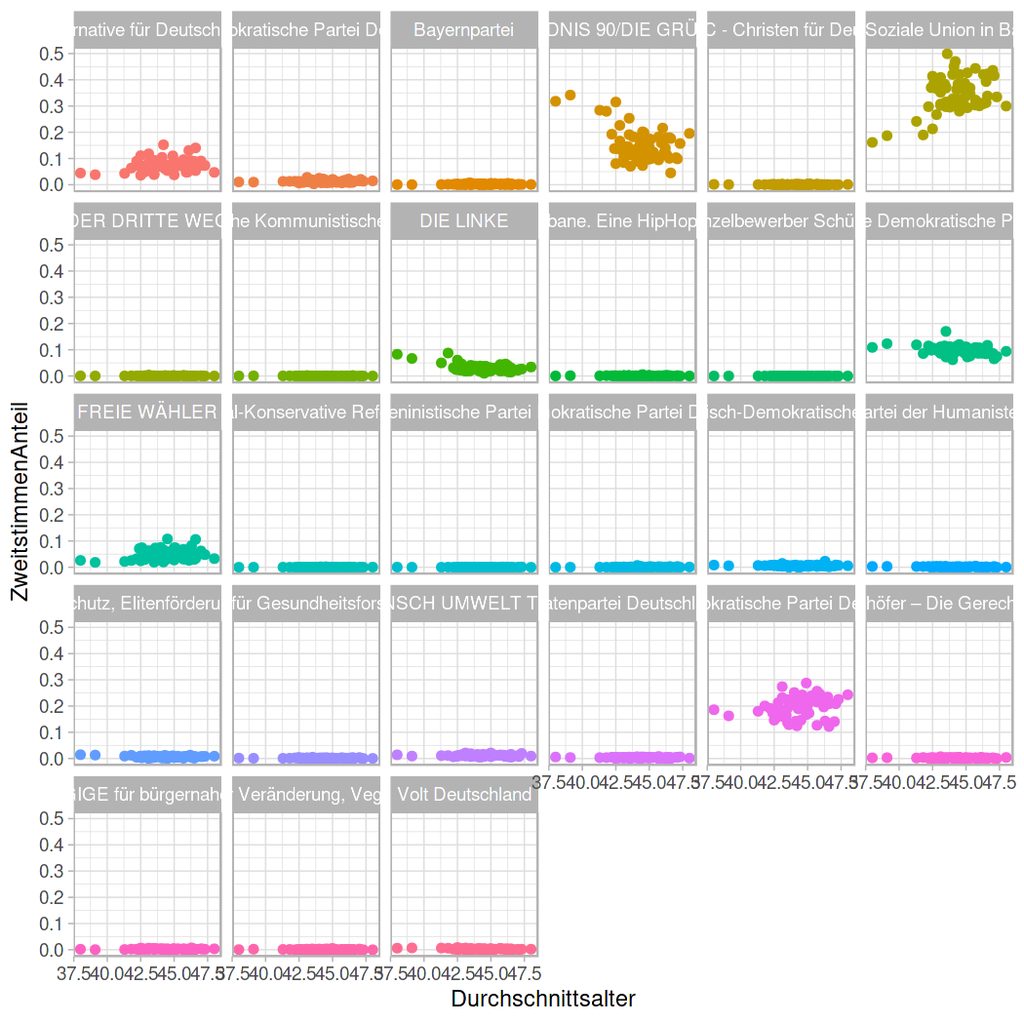

```r
data %>%
    ggplot(aes(Durchschnittsalter, ZweitstimmenAnteil, color=Partei)) +
        geom_point() + facet_wrap(~Partei) + theme(legend.position="none")
```

Es ist schwer hier etwas zu erkennen, da so viele Parteien mit extrem wenigen Stimmen das Bild füllen. Eine Idee wäre es erstmal nur Datenpunkte von >=1% Stimmanteil zu betrachten.

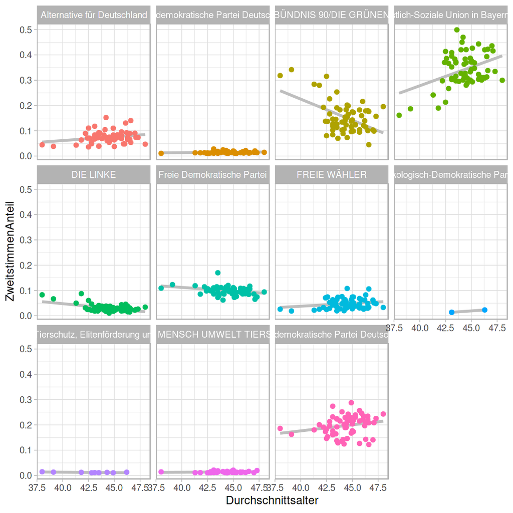

```r
data %>%
    filter(ZweitstimmenAnteil > 0.01) %>%
    ggplot(aes(Durchschnittsalter, ZweitstimmenAnteil, color=Partei)) +
        geom_smooth(method="lm", color="grey", se=FALSE) +
        geom_point() + facet_wrap(~Partei) + theme(legend.position="none")
```

Sowohl bei den Grünen als auch bei der CSU scheint ein Zusammenhang zwischen Alter und Stimmanteil zu bestehen. Allerdings in entgegengesetzte Richtung. Die Gerade dient nur der veranschaulichung. Es wurde nicht geprüft ob ein statistisch signifikanter Zusammenhang besteht.

Es könnte natürlich sein, dass der Unterschied eigentlich nicht auf das Alter sondern auf Stadt vs. Land zurückgeführt werden kann. Dies sehen wir uns mal genauer an.

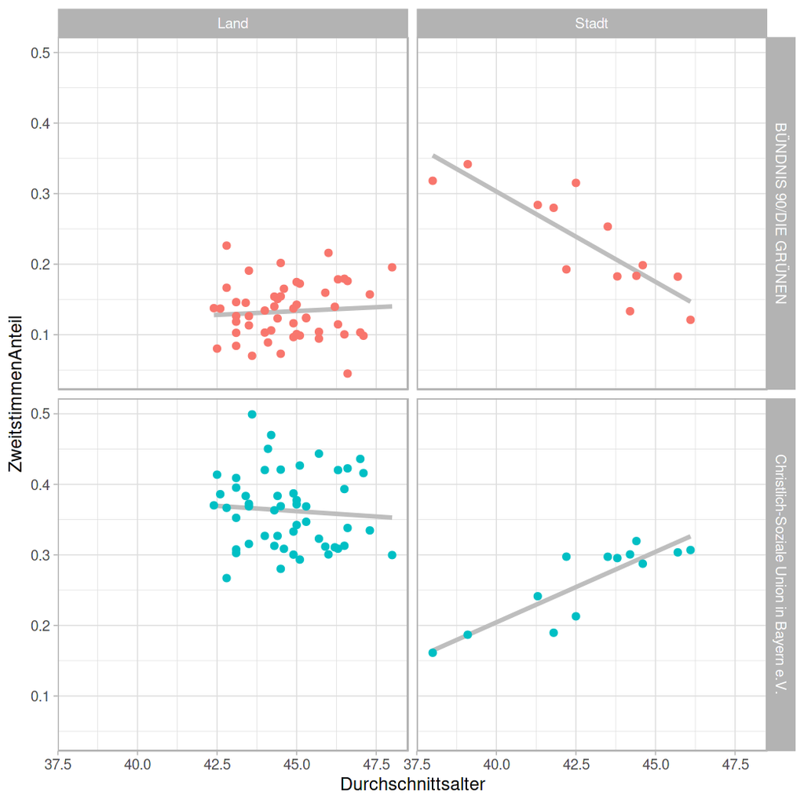

```r
data %>%
    filter(str_detect(Partei, "90|Union")) %>%
    mutate(Stadt = if_else(Stadt, "Stadt", "Land")) %>%
    ggplot(aes(Durchschnittsalter, ZweitstimmenAnteil, color=Partei)) +
        geom_smooth(method="lm", color="grey", se=FALSE) +
        geom_point() + facet_grid(Partei~Stadt) + theme(legend.position="none")
```

Tatsächlich ist kein Alterszusammenhang auf dem Land zu erkennen. In der Stadt bleibt er jedoch erhalten.

## Altersgewichtete Stimmen

```r
data %>%
    group_by(Partei) %>%
    summarize(altersSchnitt = sum(Durchschnittsalter*Zweitstimmen)/sum(Zweitstimmen), stimmen=sum(Zweitstimmen)) %>%
    filter(!is.na(altersSchnitt)) %>%
    arrange(altersSchnitt)
```

A tibble: 26 × 3

| Partei <chr> | altersSchnitt <dbl> | stimmen <dbl> |
| --- | --- | --- |
| Volt Deutschland | 42.79627 | 670 |
| Partei der Humanisten | 42.80841 | 309 |
| DIE LINKE | 42.97140 | 7025 |
| Marxistisch-Leninistische Partei Deutschlands | 43.04074 | 27 |
| BÜNDNIS 90/DIE GRÜNEN | 43.08892 | 35635 |
| Partei für Arbeit, Rechtsstaat, Tierschutz, Elitenförderung und basisdemokratische Initiative | 43.20755 | 1431 |
| Deutsche Kommunistische Partei | 43.31026 | 39 |
| V-Partei³ - Partei für Veränderung, Vegetarier und Veganer | 43.35463 | 216 |
| Team Todenhöfer – Die Gerechtigkeitspartei | 43.51986 | 433 |
| Die Urbane. Eine HipHop Partei | 43.52932 | 133 |
| Piratenpartei Deutschland | 43.53368 | 665 |
| Bündnis C - Christen für Deutschland | 43.53680 | 125 |
| Freie Demokratische Partei | 43.56377 | 19230 |
| Ökologisch-Demokratische Partei | 43.67123 | 1095 |
| PARTEI MENSCH UMWELT TIERSCHUTZ | 43.75639 | 2096 |
| Partei für Gesundheitsforschung | 43.75923 | 233 |
| Basisdemokratische Partei Deutschland | 43.80394 | 2310 |
| Sozialdemokratische Partei Deutschlands | 43.85366 | 37078 |
| DER DRITTE WEG | 43.91406 | 64 |
| Alternative für Deutschland | 44.00020 | 12217 |
| Christlich-Soziale Union in Bayern e.V. | 44.01093 | 55956 |
| FREIE WÄHLER | 44.02186 | 6871 |
| UNABHÄNGIGE für bürgernahe Demokratie | 44.03778 | 405 |
| Liberal-Konservative Reformer | 44.21463 | 41 |
| Bayernpartei | 44.22975 | 279 |
| Nationaldemokratische Partei Deutschlands | 44.41316 | 114 |

Volt hat also im Schnitt die jüngsten Wähler und die NPD die ältesten. ⚠️ So kann man das nicht sagen. Volt könnte alle Stimmen von 80 jährigen Menschen bekommen haben die in Stadtteilen mit niedrigem Durchschnittsalter leben.